# DV RProject 1

### German Martinez & Garrett Kreitman

### GFM367

**For Dr Cannata’s First Homework assignment we were; (1st) instructed to obtain data from the Titanic SQL file online. (2nd) Create an RProject where we will store an .rmd file, some data details, and a few ggplot programs. (3rd) Create an .RMD file to be KnitR-ed into this HTML file to demonstrate our process and progress through the project. (4th) Using the original Titanic Data create a data frame and several different ggplots. (5th) Lastly, come up with one ggplot on your own and explain what is its significance.**

### Steps to reproduce the project:

### First Step

To obtain the data we grabbed the contents from the link provided (in text format) and copy/pasted them onto our SQLDeveloper (which we have an account in) then ran the .txt as a script. Thus creating the Table into our Oracle account.

### Second Step

Go to RStudio and create a new project then add the 3 folders as categorized

### Third Step

Create an .rmd file that will be written then knitR-ed into this html you see right now.2

### Fourth Step

Summary

```r
source("../02 Visualizations/summary.R", echo = TRUE)
```

```
##
## > require("ggplot2")
```

```
##
## > require("jsonlite")
```

```
##
## > require("RCurl")
```

[output not shown]

Table 1

```r
source("../02 Visualizations/TitanicTable1.R", echo = TRUE)
```

```
##
## > require("ggplot2")
##
## > require("jsonlite")
##
## > require("RCurl")
##
## > df <- data.frame(fromJSON(getURL(URLencode("129.152.144.84:5001/rest/native/?query=\"select * from titanic\""),
## +     httpheader = c(DB = "jdbc:ora ..." ... [TRUNCATED]
##
## > require(extrafont)
```

```
## Registering fonts with R
```

```
##
## > ggplot(data = df, aes(x = AGE, y = FARE), color = SEX) +
## +     coord_cartesian() + scale_x_continuous() + scale_y_continuous() +
## +     labs(title  .... [TRUNCATED]
```

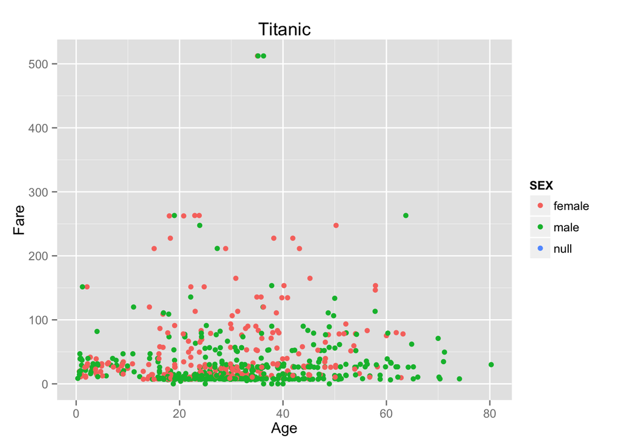

Table 2

```r
source("../02 Visualizations/TitanicTable2.R", echo = TRUE)
```

```
##
## > require("ggplot2")
##
## > require("jsonlite")
##
## > require("RCurl")
##
## > df <- data.frame(fromJSON(getURL(URLencode("129.152.144.84:5001/rest/native/?query=\"select * from titanic where sex is not null\""),
## +     httphea .... [TRUNCATED]
##
## > require(extrafont)
##
## > ggplot(data = df, aes(x = AGE, y = FARE), color = SEX) +
## +     coord_cartesian() + scale_x_continuous() + scale_y_continuous() +
## +     labs(title  .... [TRUNCATED]
```

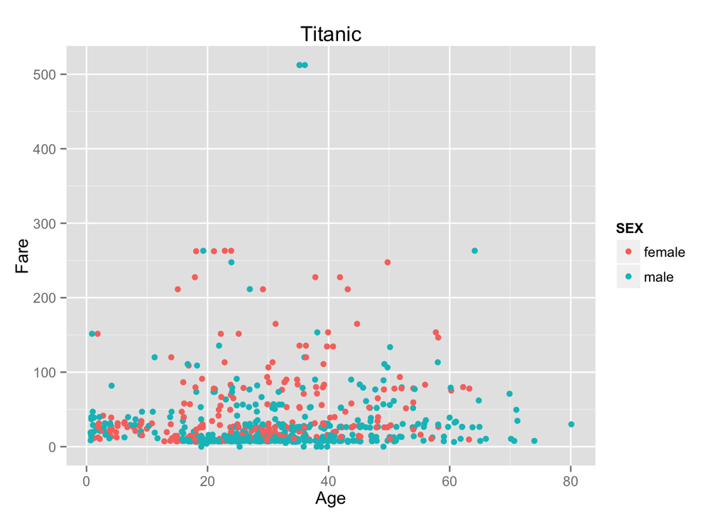

Table 3

```r
source("../02 Visualizations/TitanicTable3.R", echo = TRUE)
```

```
##
## > require("ggplot2")
##
## > require("jsonlite")
##
## > require("RCurl")
##
## > df <- data.frame(fromJSON(getURL(URLencode("129.152.144.84:5001/rest/native/?query=\"select * from titanic where sex is not null\""),
## +     httphea .... [TRUNCATED]
##
## > require(extrafont)
##
## > ggplot() + coord_cartesian() + scale_x_discrete() +
## +     scale_y_continuous() + labs(title = "Titanic") + labs(x = "SURVIVED",
## +     y = paste("F ..." ... [TRUNCATED]
```

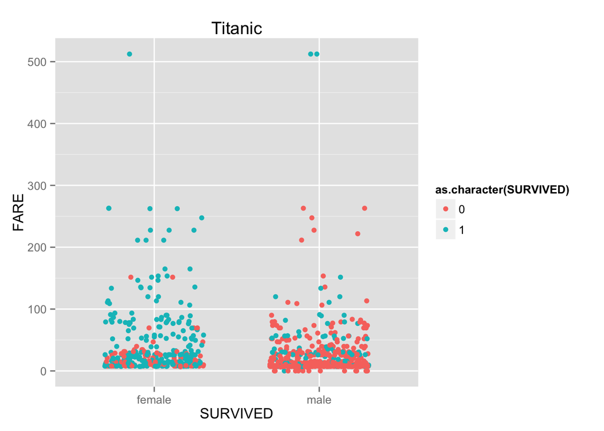

Table 4

```r
source("../02 Visualizations/TitanicTable4.R", echo = TRUE)
```

```
##
## > require("ggplot2")
##
## > require("jsonlite")
##
## > require("RCurl")
##
## > df <- data.frame(fromJSON(getURL(URLencode("129.152.144.84:5001/rest/native/?query=\"select * from titanic where sex is not null\""),
## +     httphea .... [TRUNCATED]
##
## > require(extrafont)
##
## > ggplot() + coord_cartesian() + scale_x_discrete() +
## +     scale_y_continuous() + facet_grid(PCLASS ~ SURVIVED, labeller = label_both) +
## +     labs .... [TRUNCATED]
```

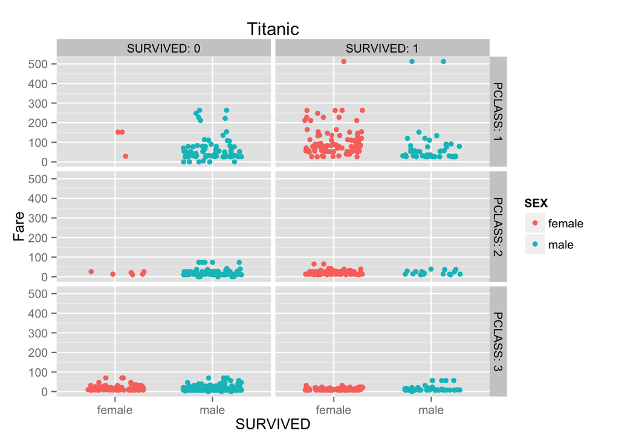

Table 5

```r
source("../02 Visualizations/TitanicTable5.R", echo = TRUE)
```

```
##
## > require("ggplot2")
##
## > require("jsonlite")
##
## > require("RCurl")
##
## > df <- data.frame(fromJSON(getURL(URLencode("129.152.144.84:5001/rest/native/?query=\"select * from titanic where age <= 10\""),
## +     httpheader =  .... [TRUNCATED]
##
## > require(extrafont)
##
## > ggplot() + coord_cartesian() + scale_x_discrete() +
## +     scale_y_continuous() + facet_grid(PCLASS ~ SURVIVED, labeller = label_both) +
## +     labs .... [TRUNCATED]
```

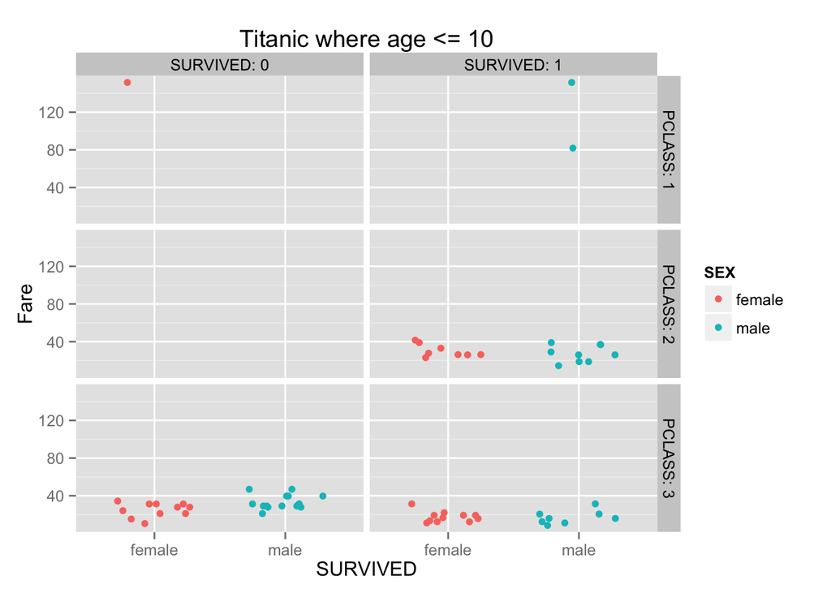

### Fifth Step

TableNew

```r
source("../02 Visualizations/TitanicTableX.R", echo = TRUE)
```

```
##
## > require("ggplot2")
##
## > require("jsonlite")
##
## > require("RCurl")
##
## > df <- data.frame(fromJSON(getURL(URLencode("129.152.144.84:5001/rest/native/?query=\"select * from titanic where survived is not null\""),
## +     ht .... [TRUNCATED]
##
## > require(extrafont)
##
## > ggplot() + coord_cartesian() + scale_x_continuous() +
## +     scale_y_continuous() + facet_grid(. ~ SURVIVED, labeller = label_both) +
## +     labs(ti .... [TRUNCATED]
```

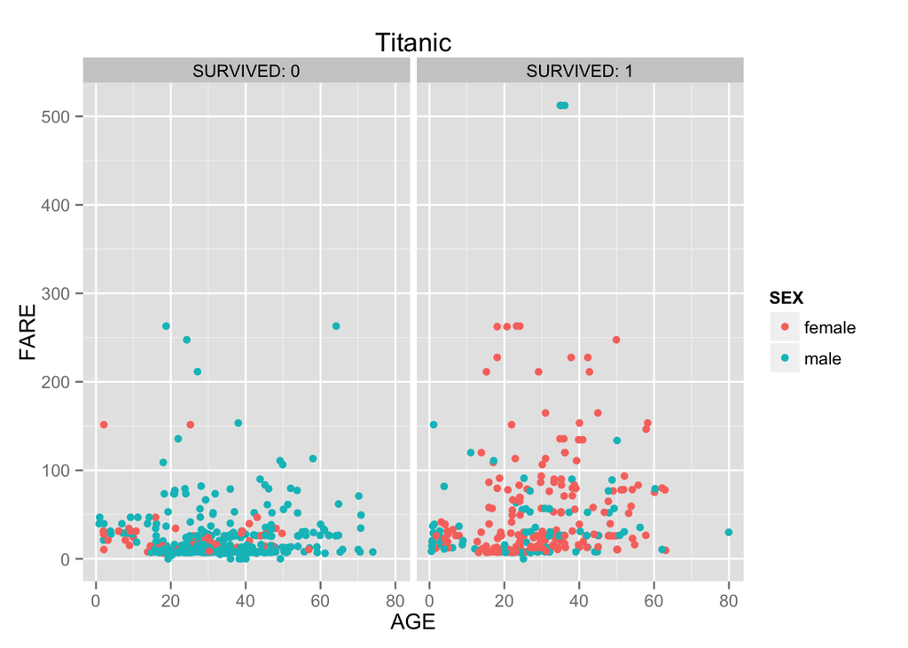

In this new table we can easily see the survived with the gender key. Using this it is easy to see on the table that there is a much larger percentage correlation that most of the woman survived over the men. This is consistant with the common saying “woman and children first” that is expected during evacuation scenarios.

**German Martinez & Garrett Kreitman GFM367 , GLK359**